# Week 9: Lab - Using aRules on the Titanic dataset

[Victor Arencibia]

[3/13/2022]

# Instructions

Use the Titanic dataset to explore descriptive statistics, functions, and association rules. Download the titanic dataset `titanic.raw.rdata` from one of two locations:

- https://github.com/ethen8181/machine-learning/tree/master/association_rule/R
- https://sites.google.com/a/rdatamining.com/www/data/titanic.raw.rdata?attredirects=1

Note that it is not a cvs file, but rather an RData workspace. So, to load the data (assuming you saved it to the project’s data folder), one would do:

`load("data/titanic.raw.rdata")`

You need to look at titanic.raw (the name of the R dataset)

`t <- titanic.raw`

Now that you have the datafile, do some descriptive statistics, getting some extra practice using R. Take the Quiz for Step 1 and 2. However your submission **MUST** include the process of you calculating the following values in Step 1 and 2.

```r
# Add your library below.

#install.packages("dplyr")
library(dplyr)
#("arules")
library(arules)
```

```r
#install.packages("arulesViz")
library(arulesViz)
require(datasets)
require(ggvis)
require(dplyr)
require(magrittr)
```

# Step 0 - Load the data

Using the instructions above, load the dataset and save it as `t`.

```r
# Write your code below.

load("data/titanic.raw.rdata")
t <- titanic.raw

summary(t)
```

```
##   Class         Sex          Age       Survived
##  1st :325   Female: 470   Adult:2092   No :1490
##  2nd :285   Male  :1731   Child: 109   Yes: 711
##  3rd :706
##  Crew:885
```

```r
length(t)
```

```
## [1] 4
```

```r
str(t)
```

```
## 'data.frame':    2201 obs. of  4 variables:
##  $ Class   : Factor w/ 4 levels "1st","2nd","3rd",..: 3 3 3 3 3 3 3 3 3 3 ...
##  $ Sex     : Factor w/ 2 levels "Female","Male": 2 2 2 2 2 2 2 2 2 2 ...
##  $ Age     : Factor w/ 2 levels "Adult","Child": 2 2 2 2 2 2 2 2 2 2 ...
##  $ Survived: Factor w/ 2 levels "No","Yes": 1 1 1 1 1 1 1 1 1 1 ...
```

# Step 1 - Descriptive stats (0.5 point for each answer)

1. Compute the percentage of people that survived.
2. Compute the percentage of people that were children.
3. Compute the percentage of people that were female.
4. Finally, compute the percentage of people that were in first class.

# Write your code below.

```r
totalpassengers <- tally(t)
totalpassengers
```

```
##      n
## 1 2201
```

```r
survivors <- filter(t, Survived == "Yes")
totalsurvivors <- tally(survivors)
totalsurvivors
```

```
##     n
## 1 711
```

```r
SurvivorPercent <- round((totalsurvivors/totalpassengers)*100)
SurvivorPercent
```

```
##    n
## 1 32
```

```r
# 32%

Children <- filter(t, Age == "Child")
Children <- tally(Children)
ChildrenPercent <- round((Children/totalpassengers)*100)
ChildrenPercent
```

```
##   n
## 1 5
```

```r
# 5%


Female <- filter(t, Sex == "Female")
Female <- tally(Female)
FemalePercent <- round((Female/totalpassengers)*100)
FemalePercent
```

```
##    n
## 1 21
```

```r
# 21 %


firstClass <- filter(t, Class == "1st")
firstClass <- tally(firstClass)
FirstClassPercent <- round((firstClass/totalpassengers)*100)
FirstClassPercent
```

```
##    n
## 1 15
```

```r
# 15%
```

# Step 2 - More descriptive stats (0.5 point for each answer)

1. What percentage of children survived? Your answer should be written such as # 13.75% of children survived
2. What percentage of female survived?
3. What percentage of first-class people survived?
4. What percentage of third-class people survived?

```r
# Write your code below.

Children2 <- t %>%
  group_by(Age,Survived) %>%
  summarise (number = n()) %>%
  mutate (freq = (number / sum(number)*100))
```

[output not shown]

```r
View(Children2)
#52.29% of children survived.

Female2 <- t %>%
  group_by(Sex,Survived) %>%
  summarise (number = n()) %>%
  mutate (freq = (number / sum(number)*100))
```

[output not shown]

```r
View(Female2)
# 73.19 of females survived

Class <- t %>%
  group_by(Class,Survived) %>%
  summarise (number = n()) %>%
  mutate (freq = (number / sum(number)*100))
Class
```

```
## # A tibble: 8 x 4
## # Groups:   Class [4]
##   Class Survived number  freq
##   <fct> <fct>     <int> <dbl>
## 1 1st   No          122  37.5
## 2 1st   Yes         203  62.5
## 3 2nd   No          167  58.6
## 4 2nd   Yes         118  41.4
## 5 3rd   No          528  74.8
## 6 3rd   Yes         178  25.2
## 7 Crew  No          673  76.0
## 8 Crew  Yes         212  24.0
```

```r
# 62.46 of first class survived
# 25.21 of Third class people survived
```

# Step 3 - Writing a function (0.5 point for each answer)

## Step 3.1 - Function 1

Write a function that returns a new dataframe of people that satisfies the specified criteria of sex, age, class and survived as parameters. I’m giving you the answer for this question:

```
myfunction1 <- function(a,b,c,d){
df1 <- t[t$Class == a,] # filter the data that satisfied the criteria that "Class" = a
df2 <- df1[df1$Sex == b,] # filter the data that satisfied the criteria that "Sex" = b
df3 <- df2[df2$Age == c,] # filter the data that satisfied the criteria that "Age" = c
df4 <- df3[df3$Survived == d,] # filter the data that satisfied the criteria that "Survived" = d
return(df4)}
# test the function with a sample data
myfunction1("1st","Female","Adult","No")
```

```r
# Write your code below.

myfunction1 <- function(a,b,c,d){
df1 <- t[t$Class == a,]
df2 <- df1[df1$Sex == b,]
df3 <- df2[df2$Age == c,]
df4 <- df3[df3$Survived == d,]
return(df4)}
# test the function with a sample data
myfunction1("1st","Female","Adult","No")
```

```
##      Class    Sex   Age Survived
## 1382   1st Female Adult       No
## 1383   1st Female Adult       No
## 1384   1st Female Adult       No
## 1385   1st Female Adult       No
```

## Step 3.2 - Function 2

Write a function, using the previous function, that calculates the percentage (who lives, who dies) for a specified (parameters) of class, gender and age considering the entire number of data. The function passes four arguments. Include the following code properly in your function by improvising names of objects.

```
p <- nrow(df)/nrow(t) # calculate the percentage
```

```r
# Write your code below.
df <- function(a,b,c,d){
df1 <- t[t$Class == a,]
df2 <- df1[df1$Sex == b,]
df3 <- df2[df2$Age == c,]
df4 <- df3[df3$Survived == d,]
count(df4)
p <- (nrow(df4)/nrow(t))*100
return(p)}
# test the function with a sample data
df("1st","Female","Adult","No")
```

```
## [1] 0.1817356
```

## Step 3.3 - Use the function (male)

Use the function to compare age and third-class male survival rates.

```r
# Write your code below.
df("3rd","Male","Child","Yes")
```

```
## [1] 0.5906406
```

```r
df("3rd","Male","Adult","Yes")
```

```
## [1] 3.407542
```

```r
# 3.4% survival rate for Adult males in 3rd class
```

People in which category are more likely to survive?

## Step 3.4 - Use the function (female)

Use the function to compare age and first-class female survival rates.

```r
# Write your code below.

df("1st", "Female","Child", "Yes")
```

```
## [1] 0.04543389
```

```r
df("1st", "Female","Adult", "Yes")
```

```
## [1] 6.360745
```

People in which category are more likely to survive?

# Step 4 - Use aRules (0.5 point for each answer)

1. Use aRules to calculate some rules (clusters) for the titanic dataset.
2. Visualize the results.
3. Pick the three most interesting and useful rules. Explain these rules using natural language. **Answer this in the space provided below.**
4. How does this compare to the descriptive analysis we did on the same data set? Think critically. What was possible using one method that was not possible using the other method? **Answer this in the space provided below.**

```r
# Write your code below.
t2 <- apriori(t, parameter = list(support=0.005,confidence=0.5))
```

```
## Apriori
##
## Parameter specification:
##  confidence minval smax arem  aval originalSupport maxtime support minlen
##         0.5    0.1    1 none FALSE            TRUE       5   0.005      1
##  maxlen target  ext
##      10  rules TRUE
##
## Algorithmic control:
##  filter tree heap memopt load sort verbose
##     0.1 TRUE TRUE  FALSE TRUE    2    TRUE
##
## Absolute minimum support count: 11
##
## set item appearances ...[0 item(s)] done [0.00s].
## set transactions ...[10 item(s), 2201 transaction(s)] done [0.00s].
## sorting and recoding items ... [10 item(s)] done [0.00s].
## creating transaction tree ... done [0.00s].
## checking subsets of size 1 2 3 4 done [0.00s].
## writing ... [132 rule(s)] done [0.00s].
## creating S4 object  ... done [0.00s].
```

```
## To reduce overplotting, jitter is added! Use jitter = 0 to prevent jitter.
```

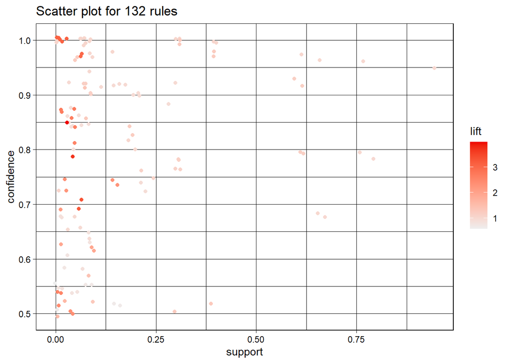

```r
plot(t2)
```

```r
inspect(sort(t2,by="lift"))
```

```
##       lhs                                       rhs            support
## [1]   {Class=2nd, Age=Adult, Survived=Yes}   => {Sex=Female}   0.036347115
## [2]   {Class=2nd, Survived=Yes}              => {Sex=Female}   0.042253521
## [3]   {Class=1st, Age=Adult, Survived=Yes}   => {Sex=Female}   0.063607451
## [4]   {Class=1st, Survived=Yes}              => {Sex=Female}   0.064061790
## [5]   {Age=Child, Survived=No}               => {Class=3rd}    0.023625625
## [6]   {Sex=Female, Age=Child, Survived=No}   => {Class=3rd}    0.007723762
## [7]   {Sex=Male, Age=Child, Survived=No}     => {Class=3rd}    0.015901863
## [8]   {Class=2nd, Age=Child}                 => {Survived=Yes} 0.010904134
## [9]   {Class=2nd, Sex=Female, Age=Child}     => {Survived=Yes} 0.005906406
## [10]  {Class=1st, Sex=Female}                => {Survived=Yes} 0.064061790
## [11]  {Class=1st, Sex=Female, Age=Adult}     => {Survived=Yes} 0.063607451
## [12]  {Class=2nd, Sex=Female}                => {Survived=Yes} 0.042253521
## [13]  {Class=Crew, Sex=Female}               => {Survived=Yes} 0.009086779
## [14]  {Class=Crew, Sex=Female, Age=Adult}    => {Survived=Yes} 0.009086779
```

[output cut: 251 more lines]

```r
inspect(sort(t2, by="support"))
```

```
##       lhs                                       rhs            support
## [1]   {}                                     => {Age=Adult}    0.950477056
## [2]   {}                                     => {Sex=Male}     0.786460700
## [3]   {Sex=Male}                             => {Age=Adult}    0.757383008
## [4]   {Age=Adult}                            => {Sex=Male}     0.757383008
## [5]   {}                                     => {Survived=No}  0.676965016
## [6]   {Survived=No}                          => {Age=Adult}    0.653339391
## [7]   {Age=Adult}                            => {Survived=No}  0.653339391
## [8]   {Survived=No}                          => {Sex=Male}     0.619718310
## [9]   {Sex=Male}                             => {Survived=No}  0.619718310
## [10]  {Sex=Male, Survived=No}                => {Age=Adult}    0.603816447
## [11]  {Age=Adult, Survived=No}               => {Sex=Male}     0.603816447
## [12]  {Sex=Male, Age=Adult}                  => {Survived=No}  0.603816447
## [13]  {Class=Crew}                           => {Age=Adult}    0.402089959
## [14]  {Class=Crew}                           => {Sex=Male}     0.391640164
```

[output cut: 251 more lines]

```r
inspect(sort(t2, by="confidence"))
```

```
##       lhs                                       rhs            support
## [1]   {Class=Crew}                           => {Age=Adult}    0.402089959
## [2]   {Class=2nd, Age=Child}                 => {Survived=Yes} 0.010904134
## [3]   {Age=Child, Survived=No}               => {Class=3rd}    0.023625625
## [4]   {Class=2nd, Survived=No}               => {Age=Adult}    0.075874602
## [5]   {Class=1st, Survived=No}               => {Age=Adult}    0.055429350
## [6]   {Class=Crew, Sex=Female}               => {Age=Adult}    0.010449796
## [7]   {Class=Crew, Survived=Yes}             => {Age=Adult}    0.096319855
## [8]   {Class=Crew, Survived=No}              => {Age=Adult}    0.305770104
## [9]   {Class=Crew, Sex=Male}                 => {Age=Adult}    0.391640164
## [10]  {Class=2nd, Sex=Female, Age=Child}     => {Survived=Yes} 0.005906406
## [11]  {Sex=Female, Age=Child, Survived=No}   => {Class=3rd}    0.007723762
## [12]  {Sex=Male, Age=Child, Survived=No}     => {Class=3rd}    0.015901863
## [13]  {Class=2nd, Sex=Female, Survived=No}   => {Age=Adult}    0.005906406
## [14]  {Class=2nd, Sex=Male, Survived=No}     => {Age=Adult}    0.069968196
```

[output cut: 251 more lines]

> [The rules lift implies that 2nd class adults that survived were likely to be Female with a lift of 3.98 likelyhood. ]